# BIOS/EPID 511 Homework 4

Devashree Pawar

## Introduction

I picked option 1 for my assignment. This homework analyzes global COVID-19 death rates and vaccination percentages using web-scraped data from Wikipedia. The URL for the COVID-19 pandemic cases and mortality by country is available here: https://en.wikipedia.org/wiki/COVID-19_pandemic_death_rates_by_country, and COVID-19 vaccine distribution by country is available here: https://en.wikipedia.org/wiki/COVID-19_vaccine. The goal is to explore relationships between mortality, vaccination rates, and geographic distribution through visualizations.

## Setup

This section loads essential R libraries for web scraping, data manipulation, and visualization. The libraries include tools for handling HTML tables, geospatial data, and creating plots.

```r
knitr::opts_chunk$set(echo = TRUE)
library(rvest)
library(dplyr)
```

```r
library(ggplot2)
library(rnaturalearth)
library(rnaturalearthdata)
library(sf)
library(stringr)
library(countrycode)
```

## Scraping the COVID-19 Data from Wikipedia

Here, data on COVID-19 death rates and vaccination percentages are extracted from Wikipedia pages. The process involves reading HTML tables and saving them as CSV files for further analysis.

### Scraping the death rates data

This subsection pulls a table of COVID-19 death rates by country from Wikipedia.

```r
death_url <- "https://en.wikipedia.org/wiki/COVID-19_pandemic_death_rates_by_country"

# Read page
page_death <- read_html(death_url)
death_table <- page_death %>%
  html_nodes("table.wikitable") %>%
  .[[1]] %>%  # The main table is the first wikitable
  html_table()

death_table
```

```
## # A tibble: 240 × 4
##    Country                `Deaths / million` Deaths    Cases
##    <chr>                  <chr>              <chr>     <chr>
##  1 World[a]               892                7,101,788 778,652,552
##  2 Peru                   6,603              221,060   4,532,724
##  3 Bulgaria               5,679              38,767    1,339,355
##  4 North Macedonia        5,429              9,991     352,093
##  5 Bosnia and Herzegovina 5,119              16,406    404,289
##  6 Hungary                5,072              49,124    2,238,461
##  7 Croatia                4,810              18,795    1,362,394
##  8 Slovenia               4,686              9,914     1,364,008
##  9 Georgia                4,519              17,151    1,864,386
## 10 Montenegro             4,317              2,654     251,280
## # ℹ 230 more rows
```

### Scraping the Vaccine percentage

This subsection extracts a table on global COVID-19 vaccine distribution. It identifies the correct table and cleans column names.

```r
vaccine_url <- "https://en.wikipedia.org/wiki/COVID-19_vaccine"

# Read page
page <- read_html(vaccine_url)

# Get all tables and their captions
tables <- page %>% html_nodes("table.wikitable")
captions <- tables %>% html_nodes("caption") %>% html_text(trim = TRUE)

# Find table with "distribution by country"
target_index <- which(str_detect(captions, regex("distribution by country", ignore_case = TRUE)))

if (length(target_index) == 0) {
  stop("Couldn't find the 'COVID-19 vaccine distribution by country' table.")
}

# Extract table
vaccine_table <- html_table(tables[[target_index]], fill = TRUE)

# --- FIX: handle blank column names safely ---
colnames(vaccine_table) <- ifelse(
  colnames(vaccine_table) == "" | is.na(colnames(vaccine_table)),
  paste0("Column_", seq_along(colnames(vaccine_table))),
  str_trim(colnames(vaccine_table))
)

# Clean up text fields
vaccine_table <- vaccine_table %>%
  mutate(across(where(is.character), str_trim))

# Optional: clean numeric-looking columns (remove commas, %)
vaccine_table <- vaccine_table %>%
  mutate(across(
    where(~ any(str_detect(., "[0-9]"))),
    ~ str_replace_all(., ",", "")
  ))

# View result
vaccine_table
```

```
## # A tibble: 223 × 4
##    Column_1 Location          `Vaccinated[b]` `Percent[c]`
##    <chr>    <chr>             <chr>           <chr>
##  1 ""       World[d][e]       5645247500      70.70%
##  2 ""       China[f]          1318026800      92.48%
##  3 ""       India             1027438900      72.08%
##  4 ""       European Union[g] 338481060       75.43%
##  5 ""       United States[h]  270227170       79.12%
##  6 ""       Indonesia         204419400       73.31%
##  7 ""       Brazil            189643420       90.17%
##  8 ""       Pakistan          165567890       67.94%
##  9 ""       Bangladesh        151507170       89.45%
## 10 ""       Japan             104740060       83.79%
## # ℹ 213 more rows
```

## Data preparation

This section cleans and combines the scraped datasets. It standardizes country names and removes irrelevant rows to create a unified dataset.

### Cleaning Death Rate Data

The death rate table is filtered to exclude aggregated rows and cleaned to convert text-based numeric columns into proper numeric formats.

```r
# Clean and standardize death_table
death_table_clean <- death_table %>%
  select(Country, `Deaths / million`, Deaths, Cases) %>%  # keep relevant columns
  filter(!str_detect(Country, "World|Europe|Total")) %>%  # remove aggregated rows
  mutate(
    # Remove commas and convert to numeric
    `Deaths / million` = as.numeric(str_replace_all(`Deaths / million`, ",", "")),
    Deaths = as.numeric(str_replace_all(Deaths, ",", "")),
    Cases = as.numeric(str_replace_all(Cases, ",", ""))
  )

death_table_clean
```

```
## # A tibble: 237 × 4
##    Country                `Deaths / million` Deaths   Cases
##    <chr>                               <dbl>  <dbl>   <dbl>
##  1 Peru                                 6603 221060 4532724
##  2 Bulgaria                             5679  38767 1339355
##  3 North Macedonia                      5429   9991  352093
##  4 Bosnia and Herzegovina               5119  16406  404289
##  5 Hungary                              5072  49124 2238461
##  6 Croatia                              4810  18795 1362394
##  7 Slovenia                             4686   9914 1364008
##  8 Georgia                              4519  17151 1864386
##  9 Montenegro                           4317   2654  251280
## 10 Czech Republic                       4107  43836 4850686
## # ℹ 227 more rows
```

### Clean the Vaccine percentage data

The vaccination table is cleaned by removing unnecessary columns, renaming fields for clarity, and converting percentage values to numeric format.

```r
# Clean vaccine_percent dataset
vaccine_percent_clean <- vaccine_table %>%
  select(-Column_1) %>%  # remove the unwanted column
  rename(
    Country = Location,
    Vaccinated = `Vaccinated[b]`,
    Percent = `Percent[c]`
  ) %>%
  filter(!str_detect(Country, "World|European Union")) %>%  # remove aggregated rows
  mutate(
    Percent = as.numeric(str_replace_all(Percent, "%", "")),  # convert to numeric
    Vaccinated = as.numeric(str_replace_all(Vaccinated, ",", "")),
    Country = str_trim(Country)
  )

# View cleaned data
vaccine_percent_clean
```

```
## # A tibble: 220 × 3
##    Country          Vaccinated Percent
##    <chr>                 <dbl>   <dbl>
##  1 China[f]         1318026800    92.5
##  2 India            1027438900    72.1
##  3 United States[h]  270227170    79.1
##  4 Indonesia         204419400    73.3
##  5 Brazil            189643420    90.2
##  6 Pakistan          165567890    67.9
##  7 Bangladesh        151507170    89.4
##  8 Japan             104740060    83.8
##  9 Mexico             97179496    75.6
## 10 Nigeria            93829430    42.0
## # ℹ 210 more rows
```

### Merge the cleaned table

This subsection merges the cleaned death and vaccination datasets by country name, creating a comprehensive dataset for visualization.

```r
# Merge death and vaccine data by country name
covid_final <- merge(death_table_clean, vaccine_percent_clean, by = "Country", all.x = TRUE)

# View summary
summary(covid_final)
```

```
##    Country          Deaths / million     Deaths            Cases
##  Length:237         Min.   :   0     Min.   :      0   Min.   :        0
##  Class :character   1st Qu.: 141     1st Qu.:    172   1st Qu.:    25292
##  Mode  :character   Median : 884     Median :   1937   Median :   191496
##                     Mean   :1263     Mean   :  30108   Mean   :  3340190
##                     3rd Qu.:1994     3rd Qu.:  14122   3rd Qu.:  1339355
##                     Max.   :6603     Max.   :1228289   Max.   :103436829
##
##    Vaccinated           Percent
##  Min.   :0.000e+00   Min.   :  0.00
##  1st Qu.:3.694e+05   1st Qu.: 44.19
##  Median :3.296e+06   Median : 67.94
##  Mean   :1.861e+07   Mean   : 62.07
##  3rd Qu.:1.111e+07   3rd Qu.: 80.19
##  Max.   :1.027e+09   Max.   :112.08
##  NA's   :22          NA's   :22
```

## Visualizing Global COVID-19 Trends

This section generates visualizations to answer research questions about death rates, vaccination coverage, and their relationships across countries and regions.

### RQ1: How do COVID-19 death rates vary across countries globally?

A choropleth map displays the variation in COVID-19 deaths per million across countries, highlighting geographic disparities.

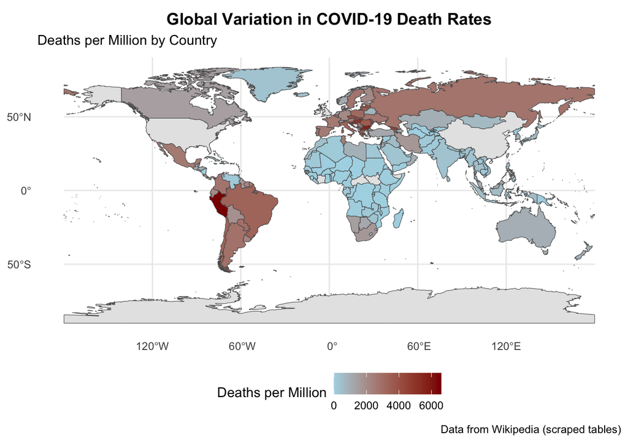

```r
# Get world map data
world <- ne_countries(scale = "medium", returnclass = "sf")

# Standardize country names in covid_final for better matching (add common aliases)
covid_final <- covid_final %>%
  mutate(Country = case_when(
    Country == "United States" ~ "USA",
    Country == "United Kingdom" ~ "UK",
    Country == "Czech Republic" ~ "Czechia",
    Country == "Democratic Republic of the Congo" ~ "Dem. Rep. Congo",
    Country == "Republic of the Congo" ~ "Congo",
    TRUE ~ Country  # Keep others as is
  ))

# Join data with map
world_covid <- world %>%
  left_join(covid_final, by = c("name" = "Country"))  # Join on country name

# Plot choropleth map
ggplot(world_covid) +
  geom_sf(aes(fill = `Deaths / million`)) +
  scale_fill_gradient(low = "lightblue", high = "darkred", na.value = "grey90",
                      name = "Deaths per Million") +
  theme_minimal() +
  labs(title = "Global Variation in COVID-19 Death Rates",
       subtitle = "Deaths per Million by Country",
       caption = "Data from Wikipedia (scraped tables)") +
  theme(legend.position = "bottom",
        plot.title = element_text(hjust = 0.5, face = "bold"))
```

### RQ2: Is there a relationship between vaccination rates and COVID-19 death rates across countries?

A scatter plot investigates whether higher vaccination rates correlate with lower COVID-19 death rates, with point sizes indicating total deaths.

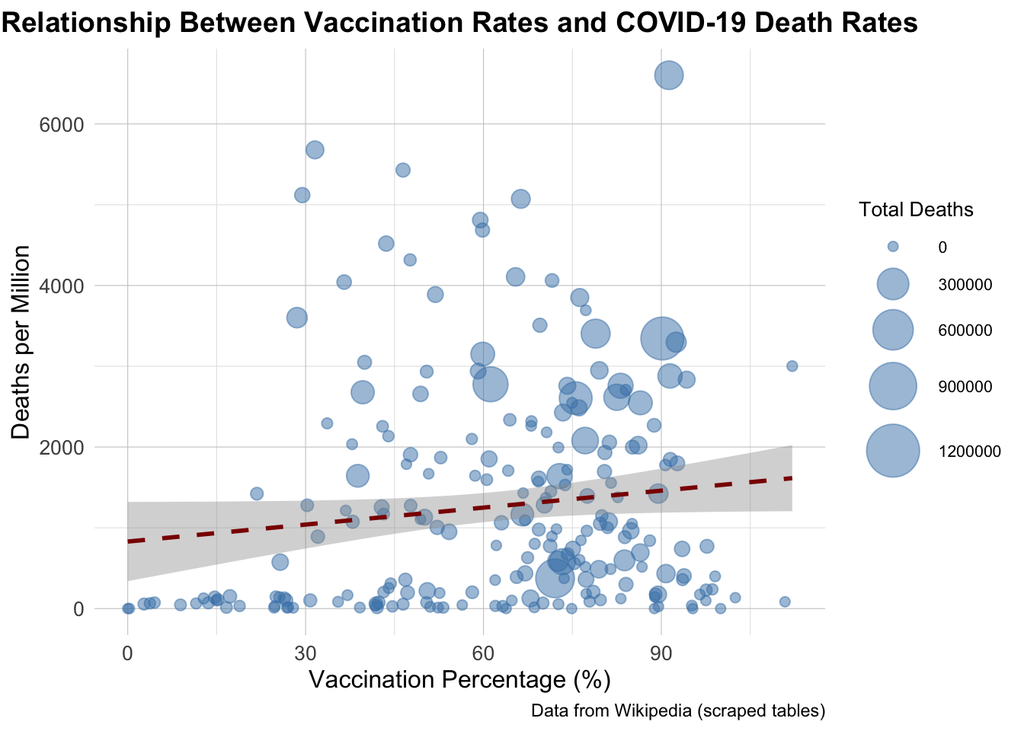

```r
ggplot(covid_final, aes(x = Percent, y = `Deaths / million`, size = Deaths)) +
  geom_point(alpha = 0.5, color = "steelblue") +  # Reduced alpha for less overlap
  geom_smooth(method = "lm", se = TRUE, color = "darkred", linetype = "dashed", size = 1.0) +  # Thicker trend line
  scale_size_continuous(name = "Total Deaths", range = c(2, 12)) +  # Larger point size range
  theme_minimal() +
  theme(
    plot.title = element_text(hjust = 0.5, face = "bold", size = 14),  # Larger title
    axis.title = element_text(size = 12),  # Larger axis labels
    axis.text = element_text(size = 10),   # Larger axis text
    legend.position = "right",            # Move legend to bottom
    legend.title = element_text(size = 10),  # Legend title size
    legend.text = element_text(size = 8),   # Legend text size
    panel.grid.major = element_line(color = "grey80", size = 0.2),  # Subtle gridlines
    panel.grid.minor = element_line(color = "grey90", size = 0.2)   # Minor gridlines
  ) +
  labs(
    title = "Relationship Between Vaccination Rates and COVID-19 Death Rates",
    x = "Vaccination Percentage (%)",
    y = "Deaths per Million",
    caption = "Data from Wikipedia (scraped tables)"
  )
```

### RQ3: How do vaccination rates and mortality rates differ by continent?

```r
# Add ISO3 codes to covid_final for reliable merging
covid_final <- covid_final %>%
  mutate(iso3 = countrycode(Country, origin = "country.name", destination = "iso3c", warn = FALSE))

# Get world map data with ISO3 and continent
world <- ne_countries(scale = "medium", returnclass = "sf") %>%
  st_drop_geometry() %>%  # Drop geometry for merging efficiency
  select(iso_a3, continent) %>%
  mutate(iso_a3 = as.character(iso_a3))  # Ensure character for joining

# Merge using ISO3 codes (handles name mismatches)
covid_with_continent <- covid_final %>%
  left_join(world, by = c("iso3" = "iso_a3")) %>%
  filter(!is.na(continent)) %>%  # Remove unmatched
  mutate(
    continent = case_when(
      continent == "Oceania" ~ "Australia",  # Rename to match your list
      TRUE ~ continent
    ),
    continent = factor(continent,
                       levels = c("Africa", "Antarctica", "Asia", "Australia",
                                  "Europe", "North America", "South America"))
  )

# Check for unmatched countries
unmatched <- covid_final %>% filter(is.na(iso3) | !(iso3 %in% world$iso_a3))
if(nrow(unmatched) > 0) {
  print("Unmatched countries:")
  print(unmatched$Country)
}
```

```
## [1] "Unmatched countries:"
##  [1] "Caribbean Netherlands" "France"                "French Guiana"
##  [4] "Gibraltar"             "Guadeloupe"            "Kosovo"
##  [7] "Martinique"            "Mayotte"               "Norway"
## [10] "Réunion"               "Tokelau"
```

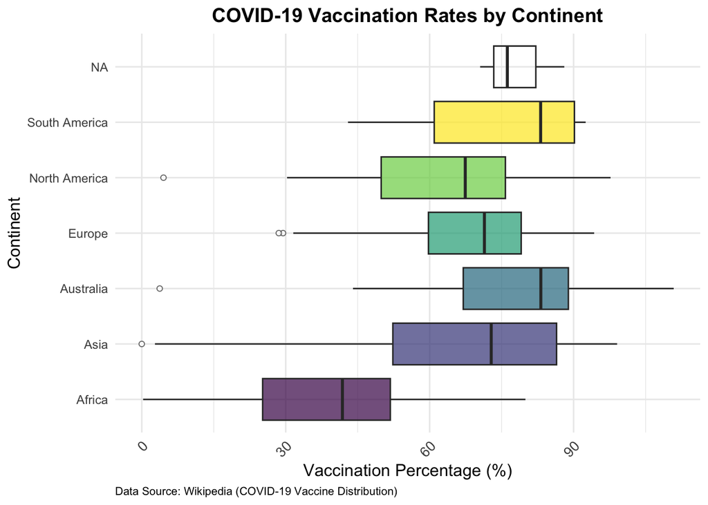

```r
# Boxplot 1: Vaccination Rates by Continent
boxplot_vaccination <- ggplot(covid_with_continent, aes(x = continent, y = Percent, fill = continent)) +
  geom_boxplot(alpha = 0.7, outlier.shape = 21, outlier.fill = "white") +
  scale_fill_viridis_d(option = "viridis", name = "Continent") +  # Updated to viridis palette
  labs(
    title = "COVID-19 Vaccination Rates by Continent",
    x = "Continent",
    y = "Vaccination Percentage (%)",
    caption = "Data Source: Wikipedia (COVID-19 Vaccine Distribution)"
  ) +
  theme_minimal() +
  theme(
    plot.title = element_text(hjust = 0.5, size = 14, face = "bold"),
    axis.title = element_text(size = 12),
    axis.text.x = element_text(angle = 45, hjust = 1, size = 10),
    legend.position = "none",
    plot.caption = element_text(size = 8, hjust = 0)
  ) +
  coord_flip()  # Horizontal boxplots for readability

# print vaccination boxplot
print(boxplot_vaccination)
```

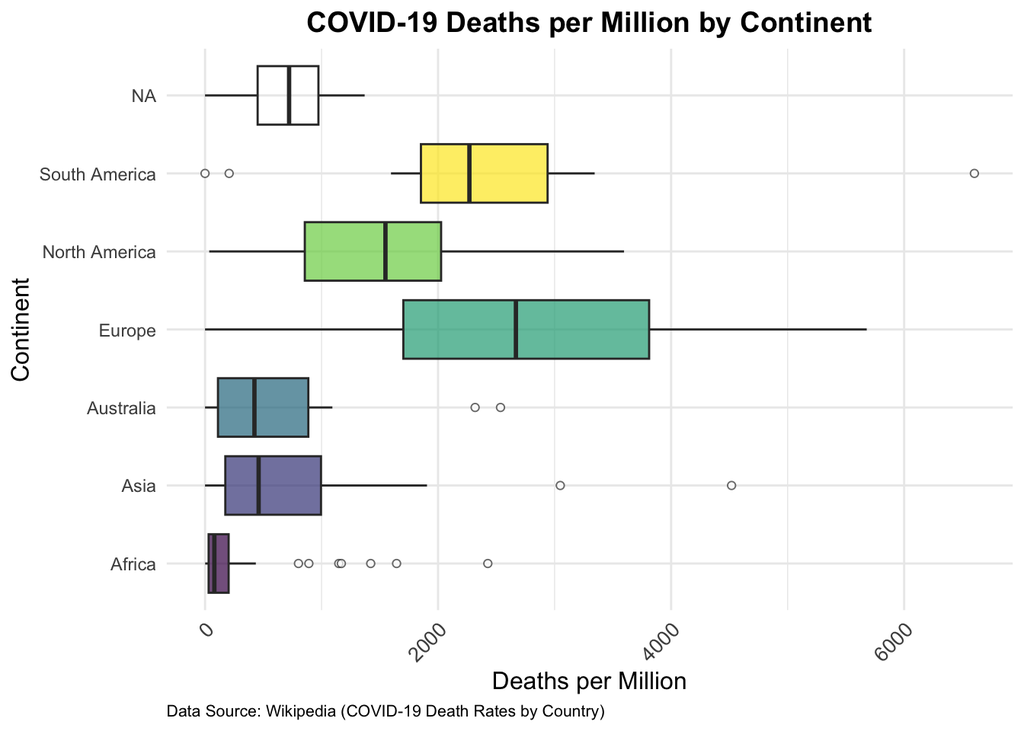

```r
# Boxplot 2: Deaths per Million by Continent
boxplot_deaths <- ggplot(covid_with_continent, aes(x = continent, y = `Deaths / million`, fill = continent)) +
  geom_boxplot(alpha = 0.7, outlier.shape = 21, outlier.fill = "white") +
  scale_fill_viridis_d(option = "viridis", name = "Continent") +  # Updated to viridis palette
  labs(
    title = "COVID-19 Deaths per Million by Continent",
    x = "Continent",
    y = "Deaths per Million",
    caption = "Data Source: Wikipedia (COVID-19 Death Rates by Country)"
  ) +
  theme_minimal() +
  theme(
    plot.title = element_text(hjust = 0.5, size = 14, face = "bold"),
    axis.title = element_text(size = 12),
    axis.text.x = element_text(angle = 45, hjust = 1, size = 10),
    legend.position = "none",
    plot.caption = element_text(size = 8, hjust = 0)
  ) +
  coord_flip()

# print deaths boxplot
print(boxplot_deaths)
```

### RQ4: What is the global distribution of vaccination rates, and how does it align with high-mortality countries?

A histogram compares vaccination rate distributions between countries with high and low COVID-19 mortality, using a threshold of 2000 deaths per million.

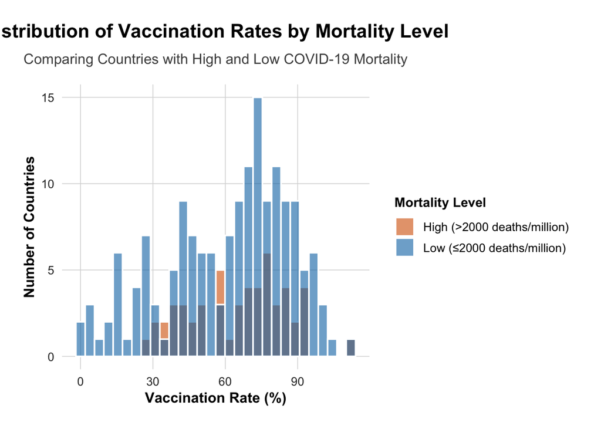

```r
# Define high/low mortality based on Deaths per million
covid_final$High_Mortality <- ifelse(covid_final$`Deaths / million` > 2000, "High", "Low")

# Create the histogram
ggplot(covid_final, aes(x = Percent, fill = High_Mortality)) +
  geom_histogram(position = "identity", alpha = 0.6, bins = 30, color = "white") +
  scale_fill_manual(values = c("High" = "#D55E00", "Low" = "#0072B2"),
                    labels = c("High (>2000 deaths/million)", "Low (≤2000 deaths/million)")) +
  labs(title = "Distribution of Vaccination Rates by Mortality Level",
       subtitle = "Comparing Countries with High and Low COVID-19 Mortality",
       x = "Vaccination Rate (%)",
       y = "Number of Countries",
       fill = "Mortality Level") +
  theme_minimal(base_size = 14) +
  theme(
    plot.title = element_text(face = "bold", hjust = 0.5, size = 16, margin = margin(b = 10)),
    plot.subtitle = element_text(hjust = 0.5, size = 12, color = "grey30", margin = margin(b = 15)),
    axis.title = element_text(face = "bold", size = 12),
    axis.text = element_text(size = 10, color = "grey20"),
    legend.position = "right",
    legend.title = element_text(face = "bold", size = 11),
    legend.text = element_text(size = 10),
    panel.grid.major = element_line(color = "grey85", linewidth = 0.3),
    panel.grid.minor = element_blank(),
    plot.margin = margin(t = 20, r = 20, b = 20, l = 20)
  )
```

**Interpretation**: The histogram compares vaccination rate distributions for countries with high (>2000 deaths per million) and low (≤2000 deaths per million) mortality. The “Low” mortality group (blue) likely shows a broader distribution, with many countries having lower vaccination rates, possibly due to limited access in developing regions. The “High” mortality group (orange) may cluster at higher vaccination percentages, reflecting stronger vaccination efforts in wealthier nations that also experienced high mortality. Overlap between the two suggests that vaccination rates alone do not fully explain mortality differences, pointing to other factors like healthcare systems or pandemic timing.

## Shiny Application link

The link for the shiny application is https://8etlvn-devashree-pawar.shinyapps.io/COVID19Analysis/. You can check it out at the provided link.